# 市场观察

2016/06/27

## 一、指数估值

### (一)指数动态市盈率

核心指数成分股的动态市盈率中位数走势如下图所示：

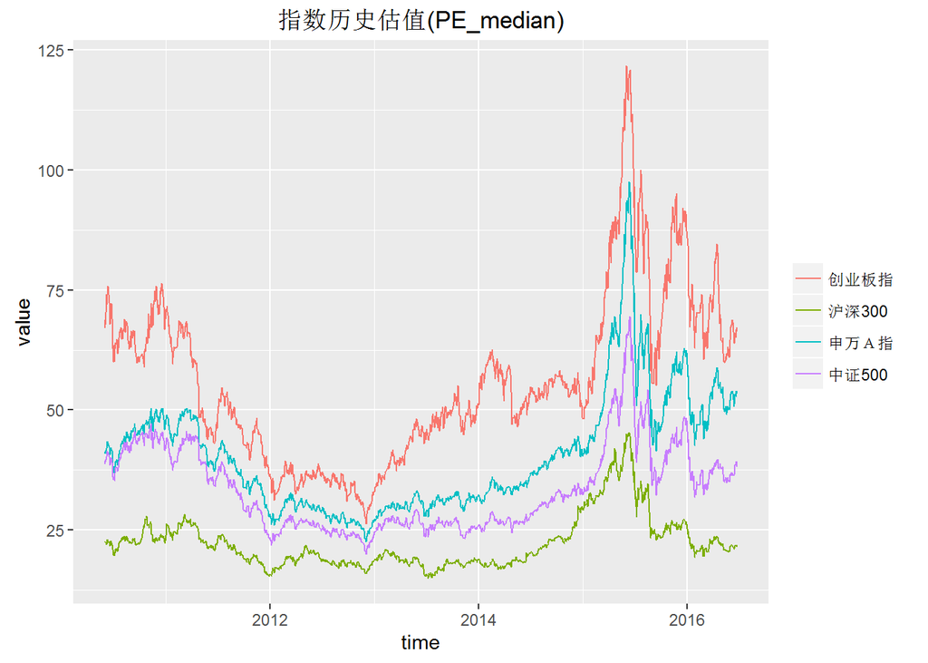

### (二)指数动态市盈率百分位

核心指数上述数据的百分位走势如下图所示：

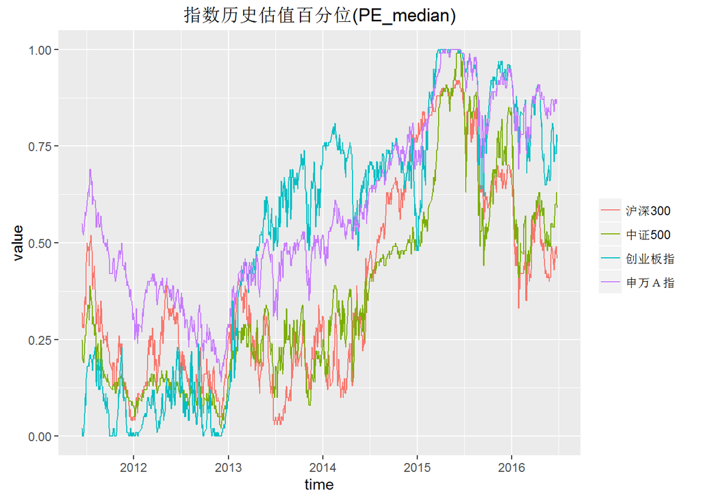

### (三)指数估值概览

纳入观察的18只指数最新的估值情况如下表：

| 日期 | 指数代码 | 指数简称 | 动态市盈率 | 上周动态市盈率 | 市盈率百分位 | 上周市盈率百分位 | 动态市净率 | 市净率百分位 |
| --- | --- | --- | --- | --- | --- | --- | --- | --- |
| 2016-06-24 | EI000819 | 有色金属 | 59.49 | 59.56 | 0.90 | 0.90 | 3.98 | 0.83 |
| 2016-06-24 | EI000979 | 大宗商品 | 43.36 | 43.65 | 0.90 | 0.91 | 2.44 | 0.42 |
| 2016-06-24 | EI801003 | 申万Ａ指 | 53.32 | 53.29 | 0.87 | 0.87 | 4.51 | 0.71 |
| 2016-06-24 | EI000805 | A股资源 | 42.32 | 44.88 | 0.81 | 0.83 | 2.33 | 0.46 |
| 2016-06-24 | EI399959 | 军工指数 | 93.23 | 88.46 | 0.81 | 0.76 | 5.78 | 0.74 |
| 2016-06-24 | EI399005 | 中小板指P | 44.34 | 44.40 | 0.79 | 0.80 | 5.04 | 0.57 |
| 2016-06-24 | EI399006 | 创业板指 | 66.26 | 65.17 | 0.76 | 0.73 | 7.62 | 0.79 |
| 2016-06-24 | EI000998 | 中证TMT | 57.35 | 55.32 | 0.75 | 0.72 | 5.65 | 0.71 |
| 2016-06-24 | EI801120 | 申万食品饮料 | 42.73 | 43.09 | 0.64 | 0.65 | 4.25 | 0.50 |
| 2016-06-24 | EI000905 | 中证500 | 38.09 | 38.47 | 0.59 | 0.60 | 3.37 | 0.51 |
| 2016-06-24 | EI399330 | 深证100 | 26.37 | 26.35 | 0.50 | 0.50 | 3.71 | 0.56 |
| 2016-06-24 | EI000300 | 沪深300 | 21.47 | 21.70 | 0.46 | 0.48 | 2.41 | 0.41 |
| 2016-06-24 | EI000933 | 中证医药 | 36.24 | 36.98 | 0.46 | 0.53 | 4.30 | 0.19 |
| 2016-06-24 | EI000808 | 医药生物 | 38.53 | 39.20 | 0.43 | 0.49 | 5.00 | 0.42 |
| 2016-06-24 | EI000932 | 中证消费 | 31.11 | 32.84 | 0.42 | 0.51 | 4.24 | 0.43 |
| 2016-06-24 | EI000827 | 中证环保 | 35.84 | 35.65 | 0.37 | 0.36 | 3.75 | 0.56 |
| 2016-06-24 | EI000934 | 中证金融 | 14.71 | 14.76 | 0.19 | 0.20 | 2.18 | 0.45 |
| 2016-06-24 | EI000016 | 上证50 | 11.43 | 11.57 | 0.04 | 0.06 | 1.43 | 0.02 |

## 二、基差

### (一)基差走势

三大股指期货隔季合约基差走势如下图：

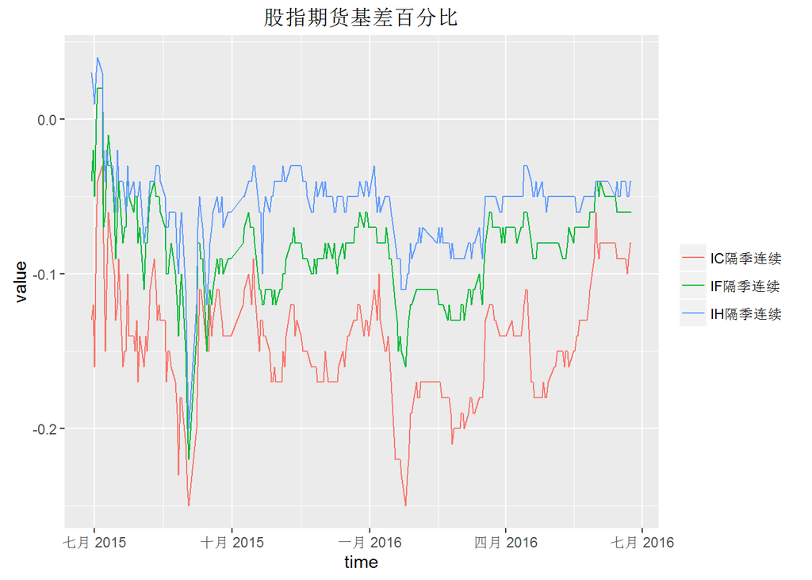

### (二)基差概况

三大股指期货连续合约基差概况如下表：

| 日期 | 合约简称 | 合约收盘价 | 基差 | 基差百分比 | 上周基差 | 上周基差百分比 |
| --- | --- | --- | --- | --- | --- | --- |
| 2016-06-24 | IH当月连续 | 2047.0 | -29.30 | -0.01 | 1.20 | 0.00 |
| 2016-06-24 | IH下月连续 | 2031.4 | -44.90 | -0.02 | -37.20 | -0.02 |
| 2016-06-24 | IH下季连续 | 2017.4 | -58.90 | -0.03 | -65.20 | -0.03 |
| 2016-06-24 | IH隔季连续 | 1992.0 | -84.30 | -0.04 | -92.40 | -0.04 |
| 2016-06-24 | IF当月连续 | 3013.2 | -63.96 | -0.02 | 3.04 | 0.00 |
| 2016-06-24 | IF下月连续 | 2983.0 | -94.16 | -0.03 | -73.96 | -0.02 |
| 2016-06-24 | IF下季连续 | 2956.4 | -120.76 | -0.04 | -134.96 | -0.04 |
| 2016-06-24 | IF隔季连续 | 2891.2 | -185.96 | -0.06 | -194.56 | -0.06 |
| 2016-06-24 | IC当月连续 | 5787.0 | -116.62 | -0.02 | -1.87 | 0.00 |
| 2016-06-24 | IC下月连续 | 5702.2 | -201.42 | -0.03 | -153.67 | -0.03 |
| 2016-06-24 | IC下季连续 | 5639.8 | -263.82 | -0.04 | -362.87 | -0.06 |
| 2016-06-24 | IC隔季连续 | 5431.0 | -472.62 | -0.08 | -560.07 | -0.09 |

## 三、套利

### (一)复牌股票套利

近两天复牌股票套利情况如下表：

[1] “无复牌股票套利”

### (二)定增基金跟踪

截止2016-06-27定增基金数据如下表，明细数据参见钱瀚的模板。

| 代码 | 名称 | 到期日期 | 最新净值 | 昨日收盘价 | 折溢价率 | 整体隐含折价率 | 大盘回撤0.1净值回撤 |
| --- | --- | --- | --- | --- | --- | --- | --- |
| 168101.OF | 九泰锐智 | 20200814 | 1.314 | 1.405 | 0.069 | 0.204 | -0.044 |
| 168102.OF | 九泰锐富 | 20210204 | 1.007 | 1.003 | -0.004 | 0.049 | -0.009 |
| 161222.OF | 国投瑞利 | 20160805 | 1.021 | 0.995 | -0.025 | 0.001 | -0.040 |
| 161225.OF | 国投瑞盈 | 20161119 | 0.952 | 0.947 | -0.005 | 0.069 | -0.070 |
| 501001.OF | 财通精选 | 20170101 | 1.014 | 0.943 | -0.070 | 0.031 | -0.090 |
| 501015.OF | 财通升级 | 20170908 | 1.009 | 0.934 | -0.074 | 0.067 | -0.021 |

定增基金近期的净值走势如下图：

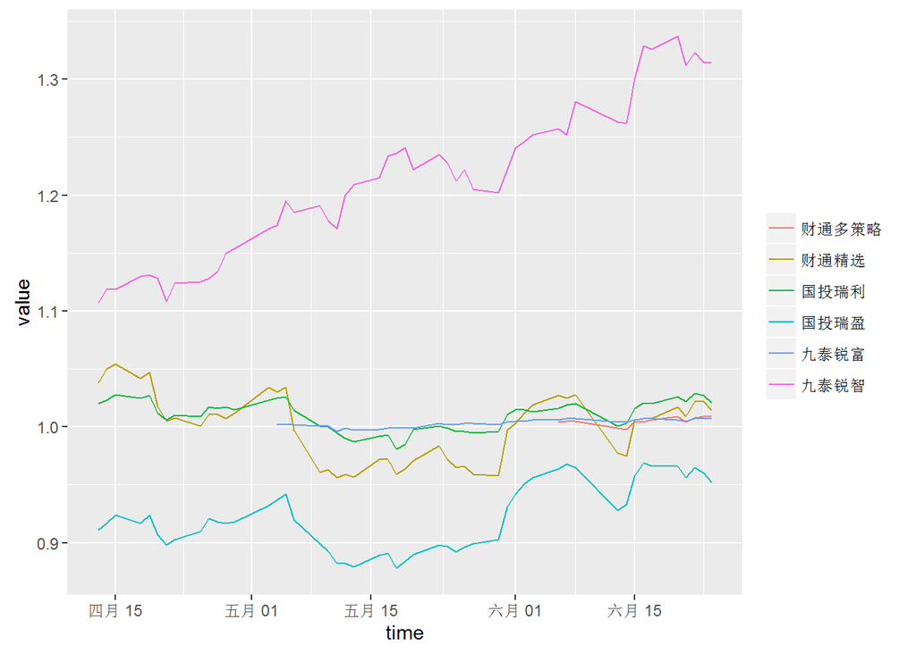

定增基金近期的折溢价走势如下图：

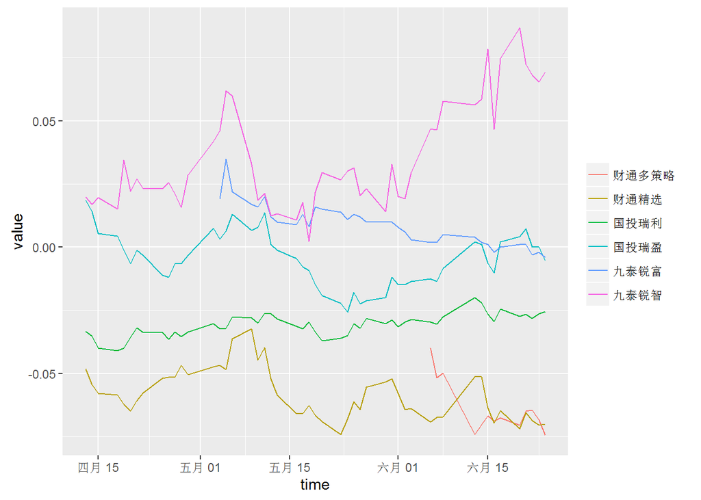

## 四、择时

### (一)大盘均线强弱指数

大盘均线强弱指数在一定程度上可以视为一个反转指标，当大盘均线得分接近8分时，预示市场接近顶部，当大盘均线得分接近0分时，预示市场接近底部。  
大盘均线强弱指数近一年来走势如下图：

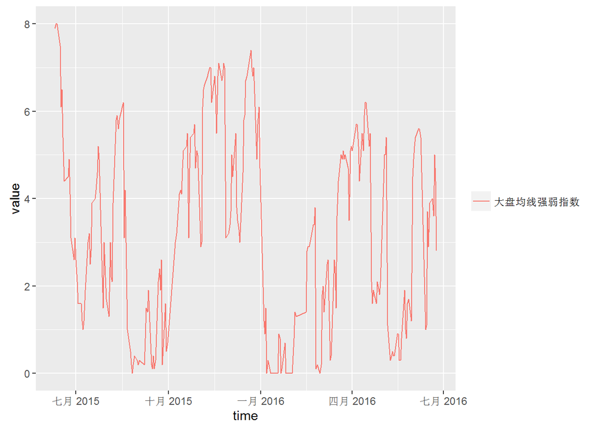

申万一级行业的最新得分及上周得分见下表：

| 日期 | 指数代码 | 指数名称 | 最新值 | 上周值 |
| --- | --- | --- | --- | --- |
| 2016-06-24 | EI801080 | 申万电子 | 8 | 8 |
| 2016-06-24 | EI801050 | 申万有色金属 | 6 | 8 |
| 2016-06-24 | EI801120 | 申万食品饮料 | 6 | 8 |
| 2016-06-24 | EI801740 | 申万国防军工 | 6 | 6 |
| 2016-06-24 | EI801750 | 申万计算机 | 6 | 3 |
| 2016-06-24 | EI801770 | 申万通信 | 6 | 6 |
| 2016-06-24 | EI801030 | 申万化工 | 5 | 6 |
| 2016-06-24 | EI801110 | 申万家用电器 | 5 | 7 |
| 2016-06-24 | EI801730 | 申万电气设备 | 5 | 6 |
| 2016-06-24 | EI801880 | 申万汽车 | 5 | 8 |
| 2016-06-24 | EI801890 | 申万机械设备 | 5 | 6 |
| 2016-06-24 | EI801140 | 申万轻工制造 | 4 | 6 |
| 2016-06-24 | EI801150 | 申万医药生物 | 4 | 5 |
| 2016-06-24 | EI801020 | 申万采掘 | 3 | 2 |
| 2016-06-24 | EI801230 | 申万综合 | 2 | 4 |
| 2016-06-24 | EI801710 | 申万建筑材料 | 1 | 3 |
| 2016-06-24 | EI801790 | 申万非银金融 | 1 | 2 |
| 2016-06-24 | EI801010 | 申万农林牧渔 | 0 | 6 |
| 2016-06-24 | EI801040 | 申万钢铁 | 0 | 2 |
| 2016-06-24 | EI801130 | 申万纺织服装 | 0 | 1 |
| 2016-06-24 | EI801160 | 申万公用事业 | 0 | 2 |
| 2016-06-24 | EI801170 | 申万交通运输 | 0 | 0 |
| 2016-06-24 | EI801180 | 申万房地产 | 0 | 1 |
| 2016-06-24 | EI801200 | 申万商业贸易 | 0 | 1 |
| 2016-06-24 | EI801210 | 申万休闲服务 | 0 | 1 |
| 2016-06-24 | EI801720 | 申万建筑装饰 | 0 | 0 |
| 2016-06-24 | EI801760 | 申万传媒 | 0 | 0 |
| 2016-06-24 | EI801780 | 申万银行 | 0 | 1 |

### (二)LLT及均线择时

LLT本质上是一个改进的单均线择时指标，较原始的均线择时延迟更低。  
择时模型和指数本身的净值走势如下图：

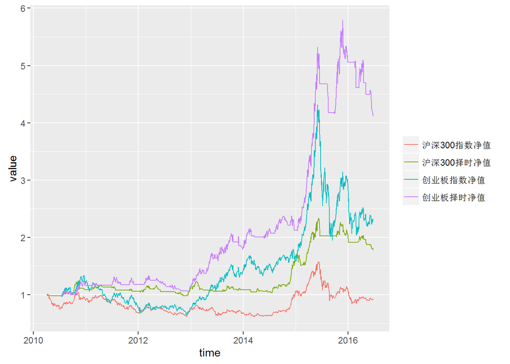

择时模型和指数的收益率统计如下表：

|  | 沪深300指 | 沪深300LLT | 创业板指 | 创业板MA |
| --- | --- | --- | --- | --- |
| 年化收益率 | -1.6 | 10.0 | 15.7 | 28.0 |
| 年化波动率 | 26.0 | 16.5 | 35.0 | 24.1 |
| 年化Sharpe值 | -6.2 | 60.9 | 44.9 | 116.4 |
| 最大回撤 | 46.7 | 24.0 | 54.9 | 28.9 |

择时模型最近10个交易日的信号如下表：

| 日期 | 沪深300收盘价 | 沪深300择时信号 | 创业板收盘价 | 创业板择时信号 |
| --- | --- | --- | --- | --- |
| 2016-06-13 | 3066.341 | sell | 2054.707 | sell |
| 2016-06-14 | 3075.983 |  | 2058.314 |  |
| 2016-06-15 | 3116.368 |  | 2128.799 | buy |
| 2016-06-16 | 3094.675 |  | 2101.416 | sell |
| 2016-06-17 | 3110.357 |  | 2122.890 | buy |
| 2016-06-20 | 3112.674 |  | 2119.630 | hold |
| 2016-06-21 | 3106.318 |  | 2092.001 | sell |
| 2016-06-22 | 3133.961 | buy | 2144.818 | buy |
| 2016-06-23 | 3117.317 | hold | 2137.485 | hold |
| 2016-06-24 | 3077.155 | sell | 2127.364 | hold |

### (三)网格交易

在经历了三轮股灾，A股逐步回归正常，在过去的一段时间呈现一个震荡的格局，如果未来没有增量信息，很可能维持震荡。结合股指期货的贴水，前期研究了一下网格交易。网格交易的结果如下图：

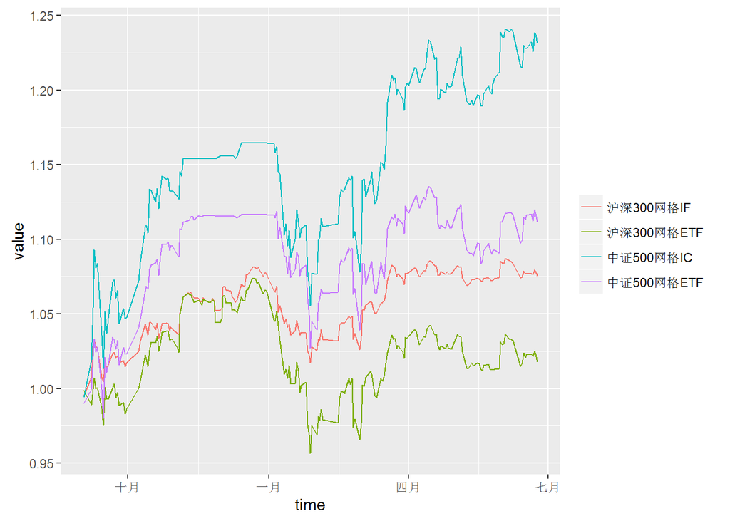

网格交易的收益统计如下表：

|  | 沪深300指数 | 沪深300网格IF | 沪深300网格ETF | 中证500指数 | 中证500网格IC | 中证500网格ETF |
| --- | --- | --- | --- | --- | --- | --- |
| 年化收益率 | -10.8 | 9.8 | 2.3 | -5.5 | 30.6 | 14.6 |
| 年化波动率 | 29.3 | 8.4 | 12.7 | 39.7 | 18.3 | 14.6 |
| 年化Sharpe值 | -36.7 | 117.2 | 18.0 | -13.8 | 167.6 | 100.1 |
| 最大回撤 | 26.4 | 5.9 | 10.9 | 33.5 | 9.4 | 8.2 |